# Decision Tree Classification — Exhaustive Visual Masterclass

## 25. Subgroup diagnostics—not fairness certification

```
region
```

|  | group | n | base_rate | roc_auc | recall | precision |
| --- | --- | --- | --- | --- | --- | --- |
| 2 | south | 111 | 0.081081 | 0.784314 | 0.666667 | 0.250000 |
| 0 | east | 118 | 0.101695 | 0.816431 | 0.750000 | 0.321429 |
| 3 | west | 131 | 0.122137 | 0.831250 | 0.750000 | 0.400000 |
| 1 | north | 120 | 0.091667 | 0.944537 | 1.000000 | 0.354839 |

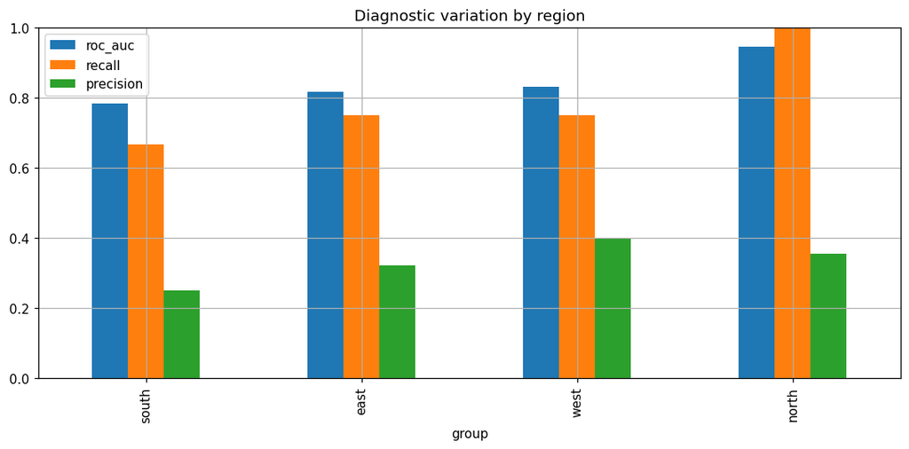

```
channel
```

|  | group | n | base_rate | roc_auc | recall | precision |
| --- | --- | --- | --- | --- | --- | --- |
| 2 | partner | 87 | 0.080460 | 0.837500 | 0.857143 | 0.272727 |
| 3 | web | 181 | 0.110497 | 0.848602 | 0.700000 | 0.325581 |
| 1 | mobile | 107 | 0.121495 | 0.851882 | 0.846154 | 0.500000 |
| 0 | branch | 105 | 0.076190 | 0.865335 | 0.875000 | 0.269231 |

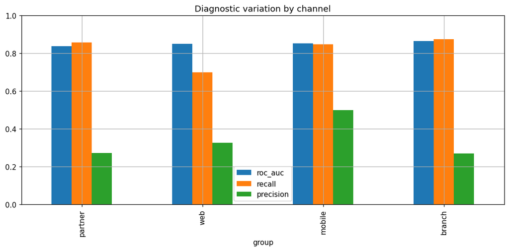

```
home_ownership
```

|  | group | n | base_rate | roc_auc | recall | precision |
| --- | --- | --- | --- | --- | --- | --- |
| 3 | RENT | 205 | 0.107317 | 0.796821 | 0.681818 | 0.348837 |
| 0 | MORTGAGE | 188 | 0.111702 | 0.889649 | 0.857143 | 0.375000 |
| 2 | OWN | 67 | 0.059701 | 0.934524 | 1.000000 | 0.222222 |
| 1 | OTHER | 13 | 0.076923 | 0.958333 | 1.000000 | 0.250000 |

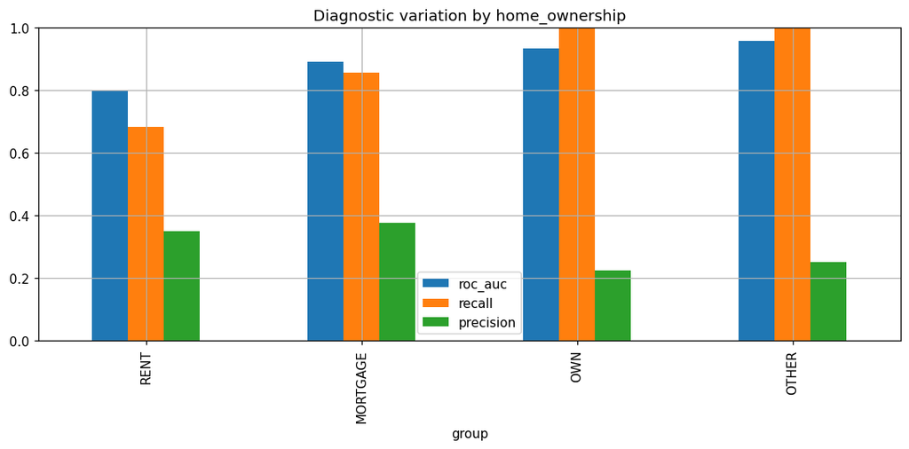

```python
valid_scored = X_valid.copy()
valid_scored["actual"] = y_valid.values
valid_scored["probability"] = selected_probability_model.predict_proba(X_valid)[:,1]
valid_scored["prediction"] = (valid_scored["probability"] >= chosen_threshold).astype(int)
for group_col in ["region", "channel", "home_ownership"]:
    rows=[]
    for group, part in valid_scored.groupby(group_col, dropna=False):
        if part["actual"].nunique() < 2: continue
        rows.append({"group": group, "n": len(part), "base_rate": part.actual.mean(), "roc_auc": roc_auc_score(part.actual, part.probability), "recall": recall_score(part.actual, part.prediction, zero_division=0), "precision": precision_score(part.actual, part.prediction, zero_division=0)})
    table = pd.DataFrame(rows).sort_values("roc_auc")
    print(group_col); display(table)
    table.set_index("group")[["roc_auc","recall","precision"]].plot(kind="bar", ylim=(0,1), title=f"Diagnostic variation by {group_col}")
    plt.tight_layout(); plt.show()
```

## 26. Robustness to plausible perturbations

```
count    480.000000
mean       0.001419
std        0.013624
min        0.000000
1%         0.000000
5%         0.000000
50%        0.000000
95%        0.000000
99%        0.068430
max        0.175291
dtype: float64
```

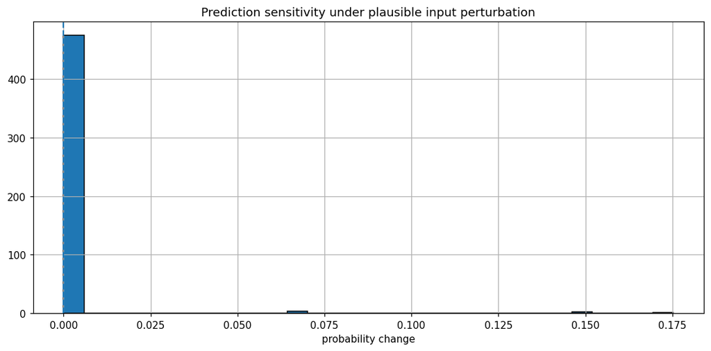

```python
base = selected_probability_model.predict_proba(X_valid)[:,1]
perturbed = X_valid.copy()
perturbed["annual_income"] = perturbed["annual_income"] * 1.05
perturbed["loan_amount"] = perturbed["loan_amount"] * 1.05
perturbed["debt_ratio"] = np.clip(perturbed["debt_ratio"] + .02, 0, 1)
shifted = selected_probability_model.predict_proba(perturbed)[:,1]
delta = shifted - base
print(pd.Series(delta).describe(percentiles=[.01,.05,.5,.95,.99]))
plt.hist(delta, bins=30, edgecolor="black")
plt.axvline(0, linestyle="--"); plt.title("Prediction sensitivity under plausible input perturbation")
plt.xlabel("probability change"); plt.tight_layout(); plt.show()
```

## 27. Final untouched-test evaluation with bootstrap uncertainty

|  | model | threshold | accuracy | balanced_accuracy | precision | recall | f1 | mcc | roc_auc | average_precision | log_loss | brier |
| --- | --- | --- | --- | --- | --- | --- | --- | --- | --- | --- | --- | --- |
| 0 | final_test | 0.11 | 0.808333 | 0.837963 | 0.328125 | 0.875 | 0.477273 | 0.458549 | 0.917945 | 0.524464 | 0.211342 | 0.064807 |

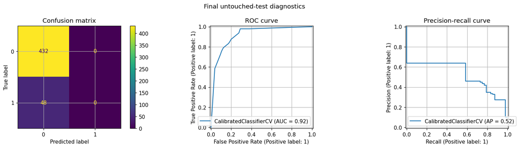

```
              precision    recall  f1-score   support

           0      0.983     0.801     0.883       432
           1      0.328     0.875     0.477        48

    accuracy                          0.808       480
   macro avg      0.656     0.838     0.680       480
weighted avg      0.917     0.808     0.842       480
```

|  | metric | estimate | ci_low | ci_high |
| --- | --- | --- | --- | --- |
| 0 | roc_auc | 0.917945 | 0.880269 | 0.952556 |
| 1 | average_precision | 0.524464 | 0.397641 | 0.656369 |
| 2 | brier | 0.064807 | 0.052365 | 0.078268 |

```python
test_proba = selected_probability_model.predict_proba(X_test)[:,1]
test_metrics = metric_row("final_test", y_test, test_proba, chosen_threshold)
display(pd.DataFrame([test_metrics]))
plot_classifier_diagnostics(selected_probability_model, X_test, y_test, "Final untouched-test diagnostics")
print(classification_report(y_test, (test_proba >= chosen_threshold).astype(int), digits=3))

rng = np.random.default_rng(RANDOM_STATE)
boot=[]
for _ in range(300):
    idx = rng.integers(0, len(y_test), len(y_test))
    yt = y_test.to_numpy()[idx]; pt = test_proba[idx]
    if np.unique(yt).size < 2: continue
    boot.append((roc_auc_score(yt, pt), average_precision_score(yt, pt), brier_score_loss(yt, pt)))
boot = np.asarray(boot)
ci = pd.DataFrame({"metric":["roc_auc","average_precision","brier"], "estimate":[test_metrics["roc_auc"],test_metrics["average_precision"],test_metrics["brier"]], "ci_low":np.quantile(boot,.025,axis=0), "ci_high":np.quantile(boot,.975,axis=0)})
display(ci)
```

## 28. Serialization, prediction contract, and model card

```python
ARTIFACT_NAME="decision_tree_classifier.joblib"
ALGORITHM_NAME="Calibrated pruned DecisionTreeClassifier"

ARTIFACT_DIR = Path("artifacts"); ARTIFACT_DIR.mkdir(exist_ok=True)
joblib.dump({"model": selected_probability_model, "threshold": chosen_threshold, "feature_columns": list(X.columns)}, ARTIFACT_DIR / ARTIFACT_NAME)

def predict_records(records: pd.DataFrame) -> pd.DataFrame:
    required = list(X.columns)
    missing = sorted(set(required) - set(records.columns))
    extra = sorted(set(records.columns) - set(required))
    if missing: raise ValueError(f"Missing required columns: {missing}")
    if extra: print("Ignoring extra columns:", extra)
    clean = records[required].copy()
    proba = selected_probability_model.predict_proba(clean)[:,1]
    return clean.assign(default_probability=proba, predicted_default=(proba >= chosen_threshold).astype(int))

display(predict_records(X_test.head(6))[["default_probability","predicted_default"] + list(X.columns[:5])])
model_card = {
    "algorithm": ALGORITHM_NAME, "intended_use": "education only", "prohibited_use": "real lending or eligibility decisions",
    "data": "deterministic synthetic teaching data", "threshold": chosen_threshold, "test_metrics": test_metrics,
    "limitations": ["synthetic data", "noncausal interpretation", "performance may drift", "subgroup diagnostics are not fairness certification"],
}
Path("model_card.json").write_text(json.dumps(model_card, indent=2), encoding="utf-8")
print(json.dumps(model_card, indent=2))
```

|  | default_probability | predicted_default | age | annual_income | employment_years | credit_score | debt_ratio |
| --- | --- | --- | --- | --- | --- | --- | --- |
| 1887 | 0.109623 | 0 | 53 | 71745.11 | 12.6 | 646 | 0.490 |
| 2064 | 0.194470 | 1 | 21 | 118491.40 | 2.2 | 637 | 0.404 |
| 1907 | 0.019179 | 0 | 31 | 77308.52 | 6.1 | 637 | 0.205 |
| 1780 | 0.019179 | 0 | 25 | 88596.50 | 7.0 | 622 | 0.214 |
| 569 | 0.019179 | 0 | 45 | 50135.82 | 6.9 | 711 | 0.282 |
| 26 | 0.292202 | 1 | 55 | 31228.96 | 1.7 | 555 | 0.184 |

```
{
  "algorithm": "Calibrated pruned DecisionTreeClassifier",
  "intended_use": "education only",
  "prohibited_use": "real lending or eligibility decisions",
  "data": "deterministic synthetic teaching data",
  "threshold": 0.11,
  "test_metrics": {
    "model": "final_test",
    "threshold": 0.11,
    "accuracy": 0.8083333333333333,
    "balanced_accuracy": 0.837962962962963,
    "precision": 0.328125,
    "recall": 0.875,
    "f1": 0.4772727272727273,
    "mcc": 0.4585485032120155,
    "roc_auc": 0.917944637345679,
    "average_precision": 0.524463909817405,
    "log_loss": 0.21134209665613882,
    "brier": 0.0648067237668532
  },
  "limitations": [
    "synthetic data",
    "noncausal interpretation",
    "performance may drift",
    "subgroup diagnostics are not fairness certification"
  ]
}
```

## 29. Failure modes and remedies

- **High variance:** constrain depth/leaf size or prune; confirm with repeated CV.
- **Fragmented categories:** inspect support before trusting category splits.
- **Unstable probabilities:** calibrate using training folds only.
- **Misleading importance:** compare MDI with permutation and inspect correlated predictors.
- **Policy leakage:** choose thresholds only on validation, never on test.
- **Distribution shift:** monitor schema, missingness, base rate, calibration, and subgroup behavior.

## 30. Mastery exercises

1. Derive Gini and entropy for three different class proportions.
2. Hand-calculate weighted impurity for a candidate split.
3. Explain why an unconstrained tree can have perfect training accuracy and poor validation AUC.
4. Re-run pruning with a one-standard-error selection rule.
5. Compare Gini, entropy, and log-loss criteria.
6. Explain why one-hot encoded categories become binary membership rules.
7. Trace one prediction from root to leaf.
8. Compare MDI and permutation importance under correlated features.
9. Design a different false-negative/false-positive cost function.
10. Write monitoring thresholds for drift, calibration, and missingness.